# Research Progress Meeting 2020-04-02

[figure not shown]

Image:Keystone pipeline leak on Oct 29, 2019. https://www.rawstory.com/2019/11/it-happens-over-and-over-and-over-and-over-keystone-pipeline-leaks-at-least-383000-gallons-of-crude-oil-in-north-dakota/

[figure not shown]

*Source: Draft Environmental Impact Assessment, DNV Consulting 2006.*

[figure not shown]

*Source: Draft Environmnental Impact Assessment, DNV Consulting 2006.*

In other words, the operator expects **one significant spill every 7 years** from the get-go.

### Let's quickly investigate the reality of keystone.

[figure not shown]

```r
oildata::add_company_names(32334)
```

'Tc Oil Pipeline Operations'

```r
keystone_candidates <- subset(incidents_2010, ID == 32334)
nrow(keystone_candidates)
```

21

```r
# us <- ggmap::get_googlemap("US", zoom = 4)
# saveRDS(us, "us_map.rds")
us <- readRDS("us_map.rds")

keystone_operator_spills <- ggmap(us) +
    geom_point(data = keystone_candidates, aes(x=long, y=lat, size = volume), alpha = 0.5)

options(repr.plot.width=8, repr.plot.height=6)
```

[figure not shown]

```r
keystone_operator_spills
```

## What, then, does safe mean?

- Safety has a very specific meaning in the industry.
- There is an expected performance. The environmental impact assessment implies that some incidents are to be expected.
- When leaks occur "that's ok", as long as they are detected fast and addressed.

Maybe I should mention how in the report, incident detection is the focus, rather than prevention. Thus, the incident count still matters? But in a paradox fashion. On the one hand, the incident count increasing is a sign progress - detection works. On the other hand, the incident count not going down is a sign of lack of progress. Now, the new Canadian initaitive toward no incidents might challenge that.

Pre-2000 data on pipeline network available from https://www.bts.gov/archive/publications/national_transportation_statistics/2009/table_01_10

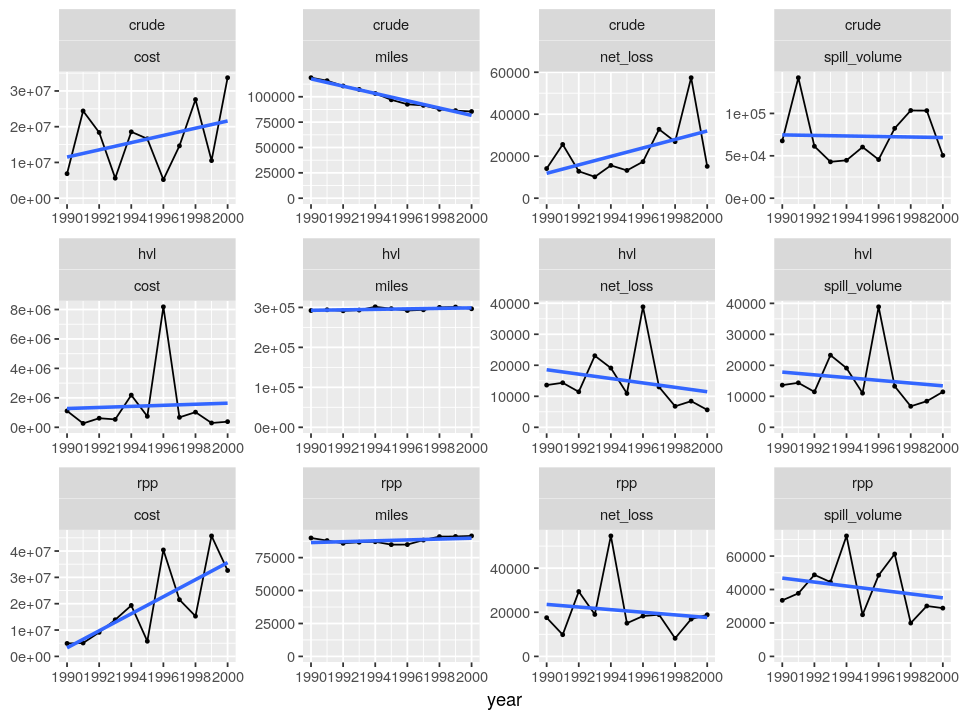

```r
pre_2000_graphed
```